# MATH439 Linear Statistical Model - HW1

Author: Yumeng Zou  
Student ID: 450801  
Due Date: Sept 7, 2018

1. Divorce in USA

```r
library(faraway)
data(divusa)
summary(divusa)
```

```
      year         divorce        unemployed         femlab
 Min.   :1920   Min.   : 6.10   Min.   : 1.200   Min.   :22.70
 1st Qu.:1939   1st Qu.: 8.70   1st Qu.: 4.200   1st Qu.:27.47
 Median :1958   Median :10.60   Median : 5.600   Median :37.10
 Mean   :1958   Mean   :13.27   Mean   : 7.173   Mean   :38.58
 3rd Qu.:1977   3rd Qu.:20.30   3rd Qu.: 7.500   3rd Qu.:47.80
 Max.   :1996   Max.   :22.80   Max.   :24.900   Max.   :59.30
    marriage          birth           military
 Min.   : 49.70   Min.   : 65.30   Min.   : 1.940
 1st Qu.: 61.90   1st Qu.: 68.90   1st Qu.: 3.469
 Median : 74.10   Median : 85.90   Median : 9.102
 Mean   : 72.97   Mean   : 88.89   Mean   :12.365
 3rd Qu.: 80.00   3rd Qu.:107.30   3rd Qu.:14.266
 Max.   :118.10   Max.   :122.90   Max.   :86.641
```

unemployed is skewed to the right, probably due to the Great Depression. \ military is skewed to the right, probably due to WWII.

```r
sort(divusa$birth)
```

```
 [1]  65.3  65.4  65.4  65.6  65.7  65.8  65.8  66.2  66.6  66.7  66.7  66.8
[13]  67.2  67.2  67.3  67.4  67.6  68.4  68.4  68.9  69.2  69.2  69.6  70.9
[25]  73.4  75.8  76.3  77.1  77.2  77.6  78.5  79.1  79.9  81.7  81.8  83.4
[37]  84.6  85.7  85.9  86.5  87.6  87.9  88.8  89.2  89.3  91.3  91.5  93.8
[49]  94.3  96.6  99.8 101.9 102.6 105.0 106.2 106.6 107.1 107.3 108.5 110.5
[61] 110.9 111.2 111.5 112.2 113.3 113.9 115.2 117.2 117.9 118.0 118.1 118.5
[73] 118.8 119.8 120.2 121.2 122.9
```

no missing value detected

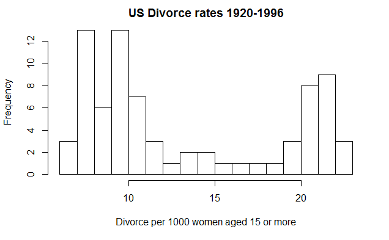

```r
hist(divusa$divorce, breaks=15, main="US Divorce rates 1920-1996", xlab="Divorce per 1000 women aged 15 or more")
```

Divorce rate in the US from 1920 to 1996 exhibits a bimodal distribution. The two modes are 9 and 21.

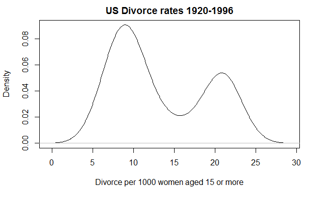

```r
plot(density(divusa$divorce,na.rm=TRUE), main="US Divorce rates 1920-1996", xlab="Divorce per 1000 women aged 15 or more")
```

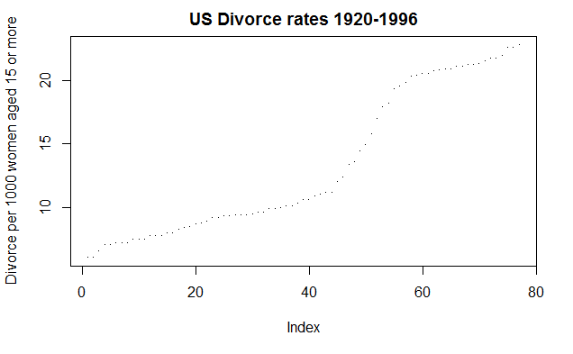

```r
plot(sort(divusa$divorce),pch='.', main="US Divorce rates 1920-1996", ylab="Divorce per 1000 women aged 15 or more")
```

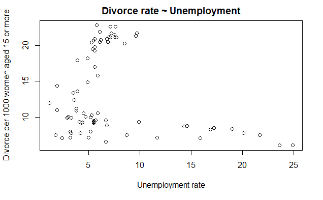

```r
plot(divorce~unemployed,divusa, main="Divorce rate ~ Unemployment", xlab="Unemployment rate", ylab="Divorce per 1000 women aged 15 or more")
```

Divorce rate can only be high when unemployment rate is low.  
When unemployment is high (above 10), divorce rate must be low.

2. alcohol

```r
bac <- c(8.2, 6.5, 2.4, 0.5, 9.6, 1.6, 5.5)
beer <- c(4.2, 3, 1.6, 0.3, 5.2, 0.7, 3.2)
alc <- data.frame(bac, beer)
alc
```

```
  bac beer
1 8.2  4.2
2 6.5  3.0
3 2.4  1.6
4 0.5  0.3
5 9.6  5.2
6 1.6  0.7
7 5.5  3.2
```

```r
lr <- lm(bac~beer, alc)
summary(lr)
```

```
Call:
lm(formula = bac ~ beer, data = alc)

Residuals:
       1        2        3        4        5        6        7
 0.26940  0.84235 -0.60588 -0.04352 -0.22472  0.29883 -0.53647

Coefficients:
            Estimate Std. Error t value Pr(>|t|)
(Intercept) -0.02472    0.39145  -0.063    0.952
beer         1.89412    0.12647  14.977  2.4e-05 ***
---
Signif. codes:  0 *** 0.001 ** 0.01 * 0.05 . 0.1   1

Residual standard error: 0.5619 on 5 degrees of freedom
Multiple R-squared:  0.9782,    Adjusted R-squared:  0.9738
F-statistic: 224.3 on 1 and 5 DF,  p-value: 2.403e-05
```

The linear regression line is $y=-0.024+1.89 \prod x$.

```r
plot(bac~beer, alc, main="Blood Alcohol Level ~ Beer", xlab="Beer (liters)", ylab="Blood Alcohol Level (%/100)")
abline(lr)
```

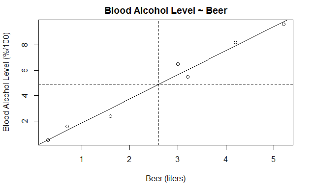

```r
abline(v=mean(beer), lty=2)
abline(h=mean(bac), lty=2)
```

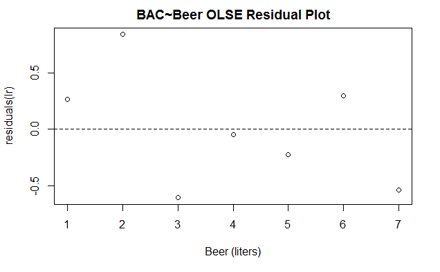

```r
plot(residuals(lr), main="BAC~Beer OLSE Residual Plot", xlab="Beer (liters)")
abline(h=0, lty=2)
```

residuals are evenly scattered around 0.  
The assumption of consistant variation is met.

3. $\hat{y}=8+3x$
- 32
- 15
- $\Delta \hat{y}=15$
4. PA housing price

```r
library(MPV)
data(table.b4)
lr <- lm(y~x1, table.b4)
summary(lr)
```

```
Call:
lm(formula = y ~ x1, data = table.b4)

Residuals:
    Min      1Q  Median      3Q     Max
-3.8343 -2.3157 -0.3669  1.9787  6.3168

Coefficients:
            Estimate Std. Error t value Pr(>|t|)
(Intercept)  13.3202     2.5717   5.179 3.42e-05 ***
x1            3.3244     0.3903   8.518 2.05e-08 ***
---
Signif. codes:  0 *** 0.001 ** 0.01 * 0.05 . 0.1   1

Residual standard error: 2.961 on 22 degrees of freedom
Multiple R-squared:  0.7673,    Adjusted R-squared:  0.7568
F-statistic: 72.56 on 1 and 22 DF,  p-value: 2.051e-08
```

5. Proof: The least-square regression line fitted to $n$ observations minimizes $\sum^{n}_{i=1}{(y_i-\hat{y})^2}$. Since $(x_{n+1},y_{n+1})$ is on the regression line, $y_{n+1}=\hat{y_{n+1}}$ and therefore $\sum^{n+1}_{i=1}{(y_i-\hat{y})^2} = \sum^{n}_{i=1}{(y_i-\hat{y})^2}$. The regression that minimizes $\sum^{n}_{i=1}{(y_i-\hat{y})^2}$ also minimizes $\sum^{n+1}_{i=1}{(y_i-\hat{y})^2}$.
6. RSS v. SSreg
4. RSS for model 1 is less than RSS for model 2, while SSreg for model 1 is greater than SSreg for model 2.